# Credit Card Users Churn Prediction

#### Bivariate Analysis Of most impactful variables

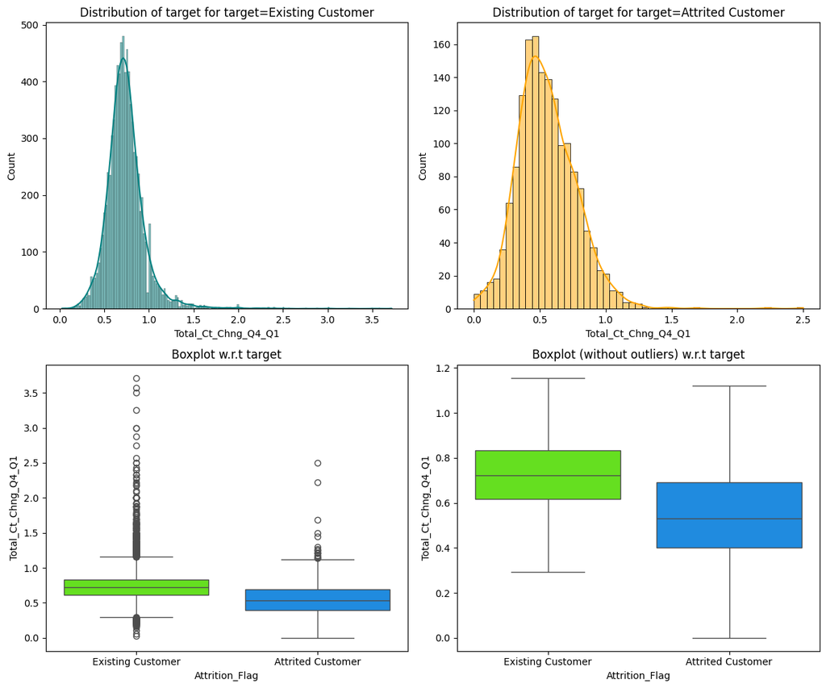

```python
distribution_plot_wrt_target(data=data, predictor='Total_Ct_Chng_Q4_Q1', target='Attrition_Flag')
```

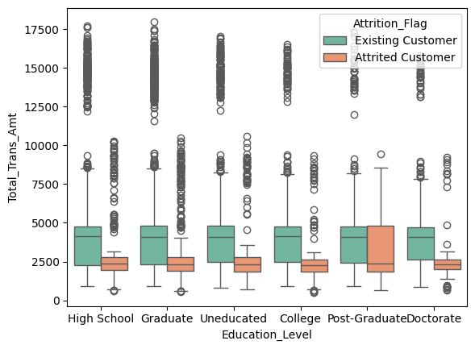

```python
sns.boxplot(data=data, x='Education_Level', y='Total_Trans_Amt', hue='Attrition_Flag', palette='Set2')
```

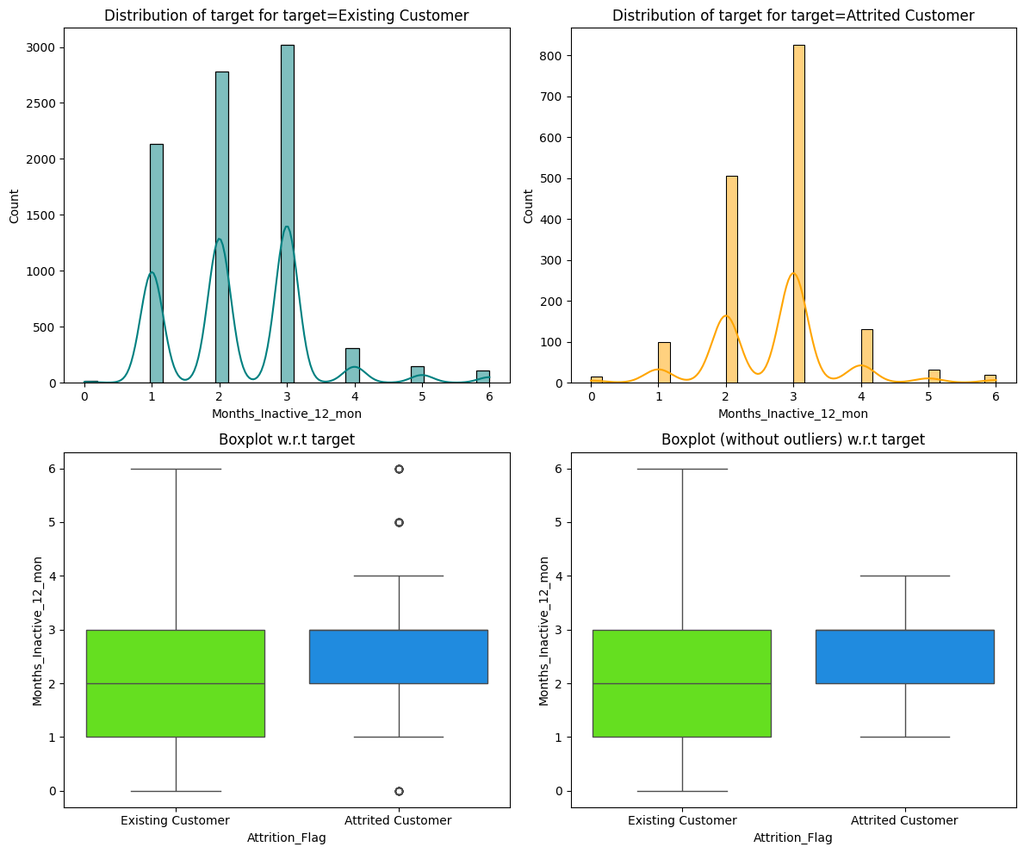

```python
distribution_plot_wrt_target(data=data, predictor='Months_Inactive_12_mon', target='Attrition_Flag')
```

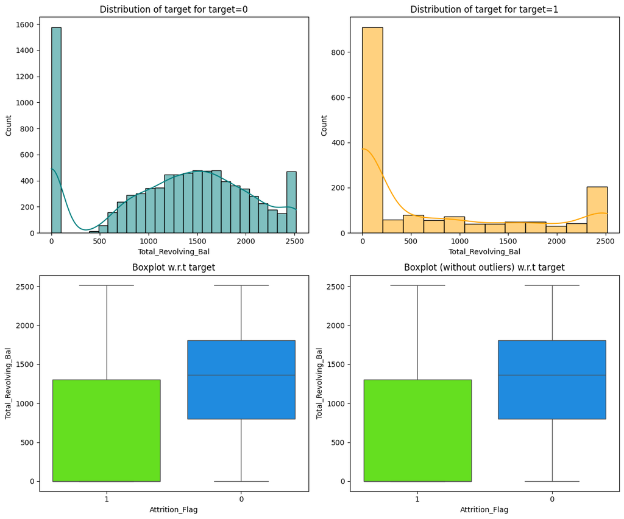

```python
distribution_plot_wrt_target(data, "Total_Revolving_Bal", "Attrition_Flag")
```

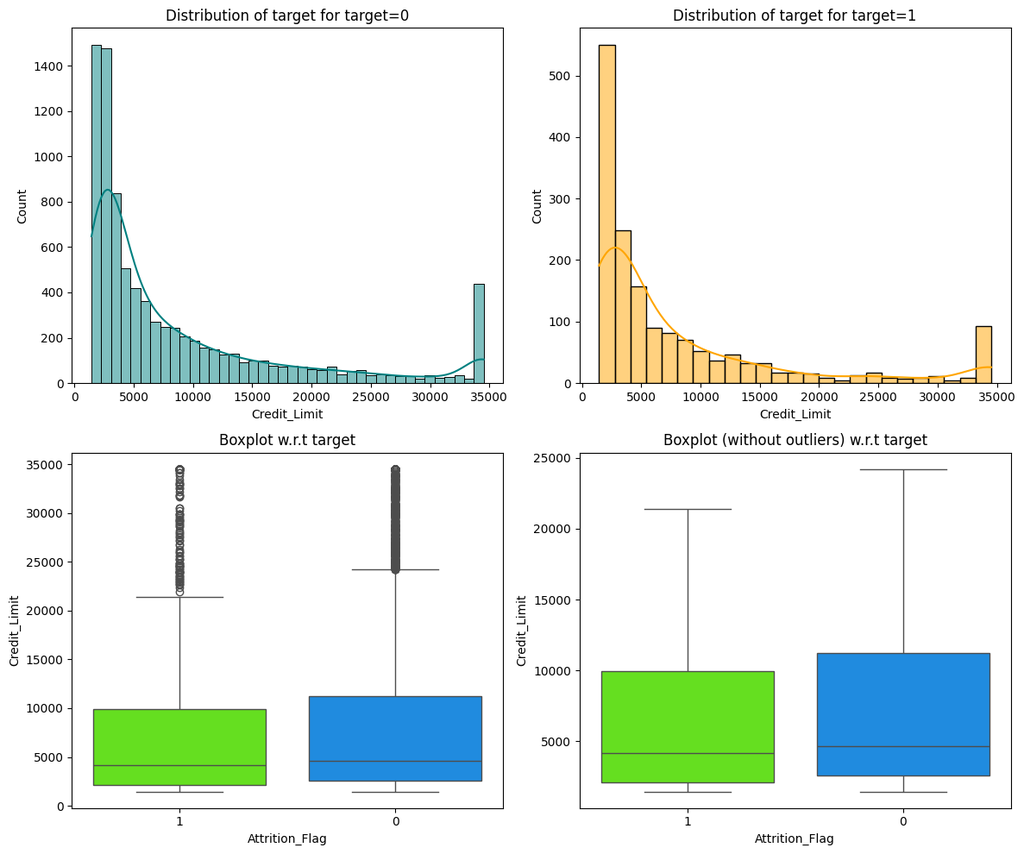

```python
distribution_plot_wrt_target(data, "Credit_Limit", "Attrition_Flag")
```

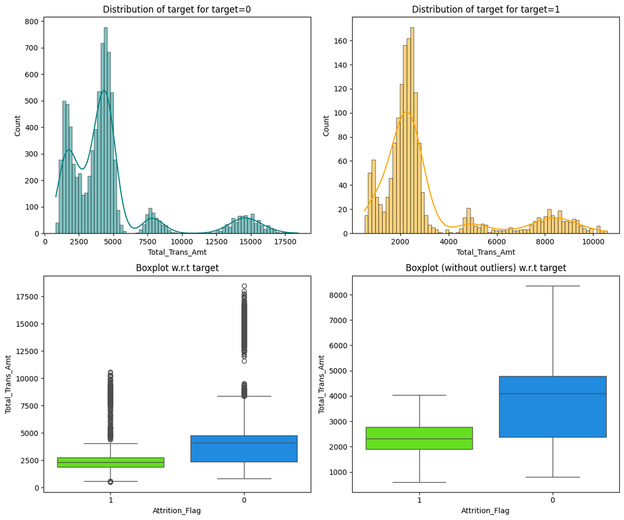

```python
distribution_plot_wrt_target(data, "Total_Trans_Amt", "Attrition_Flag")
```

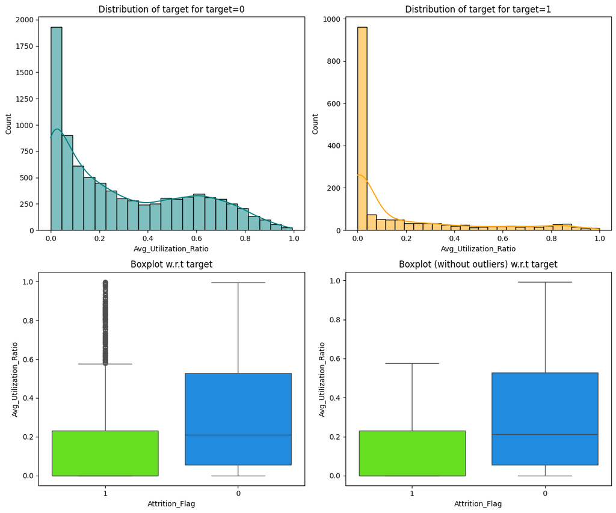

```python
distribution_plot_wrt_target(data, "Avg_Utilization_Ratio", "Attrition_Flag")
```

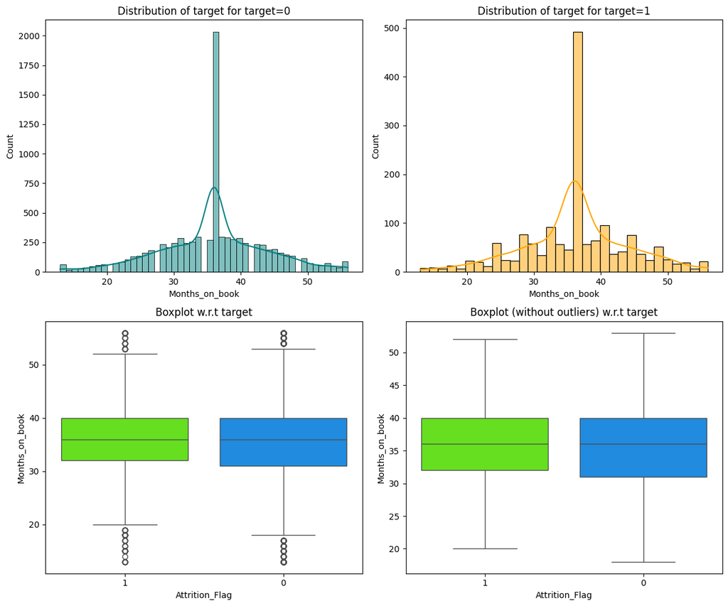

```python
distribution_plot_wrt_target(data, "Months_on_book", "Attrition_Flag")
```

**Observations**

- The variable Total_Ct_Chng_Q4_Q1 seems to be a useful predictor of customer engagement. Existing customers tend to have higher changes in transaction counts, indicating active use of their credit card services. Attrited customers, on the other hand, display lower values, suggesting reduced or inconsistent usage.
- Months of Inactivity and Total Transaction Amount are strong indicators of customer engagement and potential attrition.
- Lower transaction amounts and higher inactivity both correlate with higher churn rates.
- Income and Education Levels might offer minor insights but are less clear-cut indicators of churn compared to other metrics.
- Total Revolving Balance: Existing customers have a wider distribution across Total Revolving Balance values, while attrited customers have a higher concentration at lower balances.
- Credit Limit: Both existing and attrited customers show a similar distribution for Credit Limit, though attrited customers have slightly lower credit limits on average.
- Total Transaction Amount: Existing customers generally have higher Total Transaction Amounts than attrited customers, with a wider range of spending behavior.
- Average Utilization Ratio: Existing customers have a higher utilization ratio on average, with a significant concentration at low utilization levels among attrited customers.
- Months on Book: The distribution of months on book is similar for both existing and attrited customers, with most customers around the 36–40 month mark.